# Übungsaufgaben

## Übungsaufgaben

#### Aufgabe

1. Welche der folgenden Zeilen zeigt den Likelihood?
   1. $\mu \sim \mathcal{N}(0, 10)$
   2. $\sigma \sim \mathcal{U}(0, 1)$
   3. $y_i = \beta_0 + \beta_1\cdot x$
   4. $y_i \sim \mathcal{N}(\mu, \sigma)$

#### Lösung

   1. Falsch. Priori-Verteilung.
   2. Falsch. Priori-Verteilung.
   3. Falsch. Regressionsformel.
   4. Wahr. Likelihood.

#### Aufgabe

2. Wie viele Parameter hat das folgende Modell?

   Likelihood: $h_i \sim \mathcal{N}(\mu, \sigma)$

   Prior für $\mu$: $\mu \sim \mathcal{N}(178, 20)$

   Prior für $\sigma$: $\sigma \sim \mathcal{U}(0, 50)$
   1. 0
   2. 1
   3. 2
   4. 3
   5. mehr

#### Lösung

   1. Falsch
   2. Falsch
   3. Wahr
   4. Falsch
   5. Falsch

#### Aufgabe

3. Gegeben dem folgenden Modell, schreiben Sie die passende Form des Bayes-Theorem auf.

   Likelihood: $h_i \sim \mathcal{N}(\mu, \sigma)$

   Prior für $\mu$: $\mu \sim \mathcal{N}(178, 20)$

   Prior für $\sigma$: $\sigma \sim \mathcal{U}(0, 50)$

#### Lösung

   $$Pr(\mu, \sigma|h) = \frac{Pr(h|\mu, \sigma)\cdot Pr(\mu) \cdot Pr(\sigma)}{Pr(h)}$$

#### Aufgabe

4. Gegeben dem folgenden Modell, simulieren Sie Daten aus der Prior-Verteilung (Priori-Prädiktiv-Verteilung).

   Likelihood: $h_i \sim \mathcal{N}(\mu, \sigma)$

   Prior für $\mu$: $\mu \sim \mathcal{N}(0, 1)$

#### Lösung

   ```
   library(tidyverse)

   n <- 1e4

   sim <- tibble(
     mu = rnorm(n = n),  # Default-Werte sind mean=0, sd = 1
     sigma = runif(n = n, 0, 1)) %>%
     mutate(
       y = rnorm(n = n, mean = mu, sd = sigma))

   ggplot(sim, aes(x = y)) +
     geom_density() +
     labs(x = "y", y = "Dichte") +
     theme_minimal()
   ```

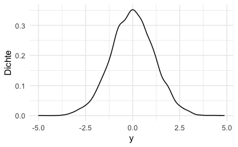

#### Aufgabe

5. Gegeben dem folgenden Modell, geben Sie den Befehl mit `quap()` an, um die Posteriori-Verteilung zu berechnen.

   Likelihood: $h_i \sim \mathcal{N}(\mu, \sigma)$

   Prior für $\mu$: $\mu \sim \mathcal{N}(0, 1)$

#### Lösung

   ```
   library(rethinking)

   model_def <-
     alist(
       y ~ dnorm(mu, sigma),
       mu ~ dnorm(0, 1),
       sigma ~ dunif(0, 1)
     )

   model <-
     quap(
       alist = model_def,
       daten = meine_Daten
     )
   ```

#### Aufgabe

6. Betrachten Sie den Datensatz zur Größe der !Kung:

   ```
   library(tidyverse)
   url_kung <- "https://raw.githubusercontent.com/rmcelreath/rethinking/master/data/Howell1.csv"
   d <-
     read_delim(url_kung, delim = ";")  # Strichpunkt als Trennzeichen in der CSV-Datei
   ```

   1. Untersuchen Sie mit Hilfe eines Diagramms, ob bzw. inwieweit sich die Größe der erwachsenen Personen normalverteilt.
   2. Kennzahlen, die angegeben, inwieweit sich eine Größe normalverteilt, sind *Schiefe* und *Kurtosis*. Die Schiefe gibt an, wie symmetrische eine Verteilung ist. Normalverteilungen sind symmetrisch und haben daher einen Wert von 0 für Schiefe. Kurtosis gibt die “Wölbung”, also wie “spitz” oder “plattgedrückt” eine Verteilung ist. Eine Normalverteilung hat eine Wert von 3 für Kurtosis. Entsprechende R-Funktionen finden Sie z.B. im Paket `moments`. Berechnen Sie die beiden Kennzahlen für die Gruppe der Erwachsenen sowie aufgeteilt nach dem Geschlecht. Interpretieren Sie das Ergebnis.
   3. Diskutieren Sie, inwieweit man aus biologisch fundierten Sachverhalten (also *ontologisch*) eine Normalverteilung der Körpergröße annehmen kann.

#### Lösung

   1. Visuelle Prüfung der Normalverteilung

   ```
   d2 <- d %>%
     filter(age >= 18)

   d3 <- d2 %>%
     select(-male)

   ggplot(d2, aes(x = height)) +
     geom_density()

   ggplot(d2, aes(x = height )) +
     facet_wrap(~ male) +
       geom_density()

   ggplot(d2, aes(x = height)) +
     facet_wrap(~ male) +
     geom_histogram(data = d3, fill = "grey60", alpha = .6) +
       geom_histogram() +
     labs(caption = "Grau hinterlegt ist das Histogramm für die Daten über beide Geschlechter")
   ```

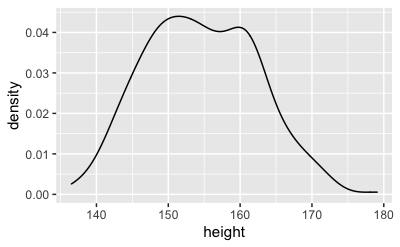

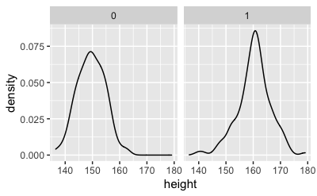

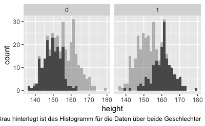

   2. Schiefe und Kurtosis

   ```
   library(moments)
   d2 %>%
     summarise(skew = skewness(height),
               kurtosis = kurtosis(height))
   ```

   | skew | kurtosis |
   | --- | --- |
   | 0.1505935 | 2.506409 |

   ```
   d2 %>%
     group_by(male) %>%
       summarise(skew = skewness(height),
               kurtosis = kurtosis(height))
   ```

   | male | skew | kurtosis |
   | --- | --- | --- |
   | 0 | 0.0036171 | 2.737863 |
   | 1 | -0.3270109 | 4.004004 |

   3. Normalverteilung, Begründung

   Es ist plausibel anzunehmen, dass der Phänotyp *Körpergröße* das Resultat des (kausalen) Einflusses vieler Gene ist, vieler Gene, die über einen vergleichbar starken Einfluss verfügen.

   Eine besondere Situation stellt das X- bzw. Y-Chromosom dar, das Gene zum Geschlecht bereitstellt. Das Geschlecht ist ein einzelner Faktor, der (erfahrungsgemäß) einen relativ großen Einfluss auf die Körpergröße hat (in Anbetracht, dass vielleicht Tausende Gene additiv die Größe bestimmen). Insofern ist eine klarere Annäherung an die Normalverteilung zu erwarten, wenn man die Geschlechter einzeln betrachtet.

#### Aufgabe

7. Pupillendaten sind ein verbreiteter Analysegegenstand in Bereichen wie Psychologie, Marktforschung und Marketing.

   Betrachten wir dazu ein R-Paket (zum Vorverbarbeitung, preprocessing) und eine Datensatz der [Uni Münster](http://cran.uni-muenster.de/web/packages/PupilPre/vignettes/PupilPre_Basic_Preprocessing.html).

   ```
   library(PupilPre)
   data("Pupildat")
   d <-
     Pupildat %>%
     select(size = RIGHT_PUPIL_SIZE,
            time = TIMESTAMP) %>%
     mutate(size = size / 100) # in millimeter
   ```

   Mit dem R-Paket `rstatix` kann man sich bequem typische Statistiken ausgeben lassen. Aber natürlich können Sie auch mit `summarise(mw = mean(size))` arbeiten.

   ```
   library(rstatix)
   d %>%
     get_summary_stats()
   ```

   | variable | n | min | max | median | q1 | q3 | iqr | mad | mean | sd | se | ci |
   | --- | --- | --- | --- | --- | --- | --- | --- | --- | --- | --- | --- | --- |
   | size | 45343 | 1.04 | 25.01 | 8.18 | 6.64 | 10.52 | 3.88 | 2.595 | 10.006 | 5.107 | 0.024 | 0.047 |
   | time | 46950 | 1443974.00 | 4062110.00 | 3629368.00 | 1874223.00 | 3821381.00 | 1947158.00 | 507873.526 | 2990837.173 | 987453.837 | 4557.210 | 8932.197 |

   Wir verzichten hier auf eine Aufbereitung der Daten (was eigentlich nötig wäre, aber nicht Gegenstand dieser Übung ist). Stattdessen konzentrieren wir uns auf die Posteriori-Verteilung zur Pupillengröße.
   1. Formulieren Sie ein passendes Modell.
   2. Verteidigen Sie Ihre Modellspezifikation.
   3. Simulieren Sie Daten aus der Priori-Verteilung. Kritisieren Sie die Wahl der Priori-Werte.
   4. Berechnen Sie die Posteriori-Verteilung mit den Pupillendaten `d`. Geben Sie zentrale Statistiken an.
   5. Geben Sie ein 90%-Intervall für die mittlere Pupillengröße an auf Basis der Posteriori-Verteilung.

#### Lösung

   1. Modelldefinition

   $$\begin{aligned}
   s_i &\sim \mathcal{N}(\mu, \sigma)\qquad \text{| s wie size }\\
   \mu &\sim \mathcal{N}(10, 5)\\
   \sigma &\sim \mathcal{U}(0, 20)
   \end{aligned}$$
   2. Begründung der Modellspezifikation

   $s_i$: Pupillengrößen sind normalverteilt, da viele Gene additiv auf die Größe hin zusammenwirken

   $\mu$: Da wir nicht viel wissen über die mittlere Pupillengröße, entscheiden wir uns für Normalverteilung für diesen Parameter, da dies keine weiteren Annahmen (außer dass Mittelwert und Streuung endlich sind) hinzufügt. Ein Modell mit wenig Annahmen nennt man “sparsam” oder konservativ. Es ist wünschenswert, dass Modelle mit so wenig wie möglich Annahmen auskommt (aber so vielen wie nötig).

   $\sigma$: Die Streuung muss positiv sein, daher kommt keine Normalverteilung in Frage. Da wir (noch) keine passenden Verteilungen kennen außer der Gleichverteilung, entscheiden wir uns für eine vage Gleichverteilung. Die große Stichprobe wird den Priori-Wert vermutlich überstimmen.
   3. Priori-Prädiktiv-Verteilung

   ```
   n <- 1e4
   sim_prior_pred <-
     tibble(
       mu = rnorm(n, mean = 10, sd = 5),
       sigma = runif(n, min = 0, max = 20),
       size = rnorm(n, mu, sigma)
     )

   sim_prior_pred %>%
     ggplot(aes(x = size)) +
     geom_density()
   ```

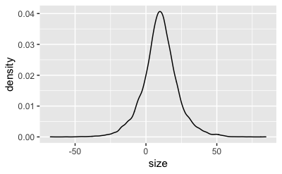

   Da es viele negative Pupillengröße-Werte gibt, sieht man deutlich, dass das Modell nicht gut spezifiziert ist. So könnte kleinere Streuungswerte zu einem realistischeren Modell führen. Oder man verwendet Verteilungen, die rein positiv sind (hier nicht weiter ausgeführt).
   4. Berechnen Sie die Posteriori-Verteilung.

   Die Modelle wie `quap()` tun sich leichter, wenn man nur die relevanten Daten, ohne fehlende Werte und schon schön fertig vorverarbeitet, zur Analyse in die Modellberechnung gibt:

   ```
   d3 <-
     d %>%
     select(size) %>%
     drop_na()
   ```

   ```
   m_pupil <-
     quap(
       alist(
         size ~ dnorm(mu, sigma),
         mu ~ dnorm(10, 5),
         sigma ~ dunif(0, 20)
       ),
       data = d3
     )
   ```

   ```
   precis(m_pupil)
   ```

   | mean | sd | 5.5% | 94.5% |
   | --- | --- | --- | --- |
   | 10.01 | 0.02 | 9.97 | 10.04 |
   | 5.11 | 0.02 | 5.08 | 5.13 |

   5. Geben Sie ein 90%-Intervall für die mittlere Pupillengröße an auf Basis der Posteriori-Verteilung.

   Ziehen wir Stichproben aus der Posteriori-Verteilung:

   ```
   post_m_pupil <-
     extract.samples(m_pupil, n = 1e4)
   ```

   ```
   library(rethinking)

   post_m_pupil %>%
     summarise(HPDI(mu))
   ```

   | HPDI(mu) |
   | --- |
   | 9.968044 |
   | 10.043803 |

#### Aufgabe

8. In diesem Diagramm sehen Sie etwas Nomenklatur für eine Verteilung: Gipfel (Peak), Schultern (shoulders) und Ränder (tails). Bitte klicken Sie den Link, um sich das Diagramm anzuschauen.

   Taleb, N. N. (2019). *The statistical consequences of fat tails, papers and commentaries*. https://nassimtaleb.org/2020/01/final-version-fat-tails/

   Zwar sind viele Daten in der Welt normalverteilt, aber längst nicht alle. In jüngerer Zeit sind sog. “Fat Tails” in die Aufmerksamkeit gerückt. Das sind Variablen, bei denen Werte in den Rändern (tails) wahrscheinlicher sind als bei einer Normalverteilung; ein Beispiel für eine [Fat-Tail-Verteilung ist die t-Verteilung mit 1 Freiheitsgrad](https://en.wikipedia.org/wiki/Student%27s_t-distribution#/media/File:Student_t_pdf.svg). Sie müssen diese Verteilung nicht weiter kennen, aber Sie sollten wissen, dass es sich um eine Fat-Tail-Verteilung handelt.

   Recherchieren Sie (Fach-)Artikel, die argumentieren, dass ein bestimmtes Phänomen Fat-Tails zeigt!

#### Lösung

   - [Kriege](https://papers.ssrn.com/sol3/papers.cfm?abstract_id=2876315)
   - [Pandemien](https://www.nature.com/articles/s41567-020-0921-x)
   - [Erfolg auf der Singlebörse Tinder](https://medium.com/@worstonlinedater/tinder-experiments-ii-guys-unless-you-are-really-hot-you-are-probably-better-off-not-wasting-your-2ddf370a6e9a)
   - [Kapitelmarkt](https://www.nasdaq.com/articles/fat-tail-risk-what-it-means-and-why-you-should-be-aware-it-2015-11-02)